# ARMAPredictions

cyber-atlas

4/28/2019

```r
library('quantmod')
library(tidyquant)
library('forecast')
```

```r
library('ggplot2')
```

First we will start out by getting the symbols that we need

```r
getSymbols("SPY", src="yahoo", from="2019-01-01")
```

[output not shown]

```
## [1] "SPY"
```

```r
getSymbols("AAPL", src="yahoo", from="2019-01-01")
```

```
## [1] "AAPL"
```

Let’s visualize the chart

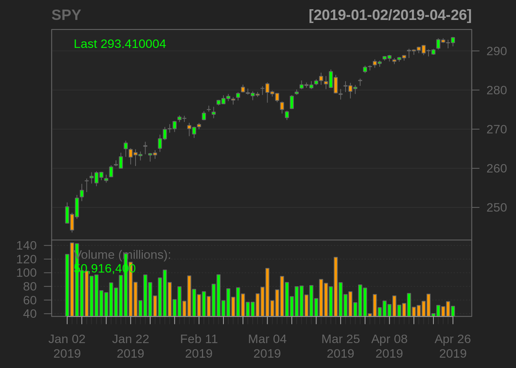

```r
chartSeries(SPY)
```

```r
Returns <- diff(SPY$SPY.Close)/lag(SPY$SPY.Close, k=1)*1000
tail(Returns, 10)
```

```
##             SPY.Close
## 2019-04-12  6.7659452
## 2019-04-15 -0.6548215
## 2019-04-16  0.6552505
## 2019-04-17 -2.4468982
## 2019-04-18  1.9691725
## 2019-04-22  0.8620095
## 2019-04-23  8.9916839
## 2019-04-24 -2.2193185
## 2019-04-25 -0.6160319
## 2019-04-26  4.6567918
```

Let’s plot a histogram of the returns to visualize how well it performs

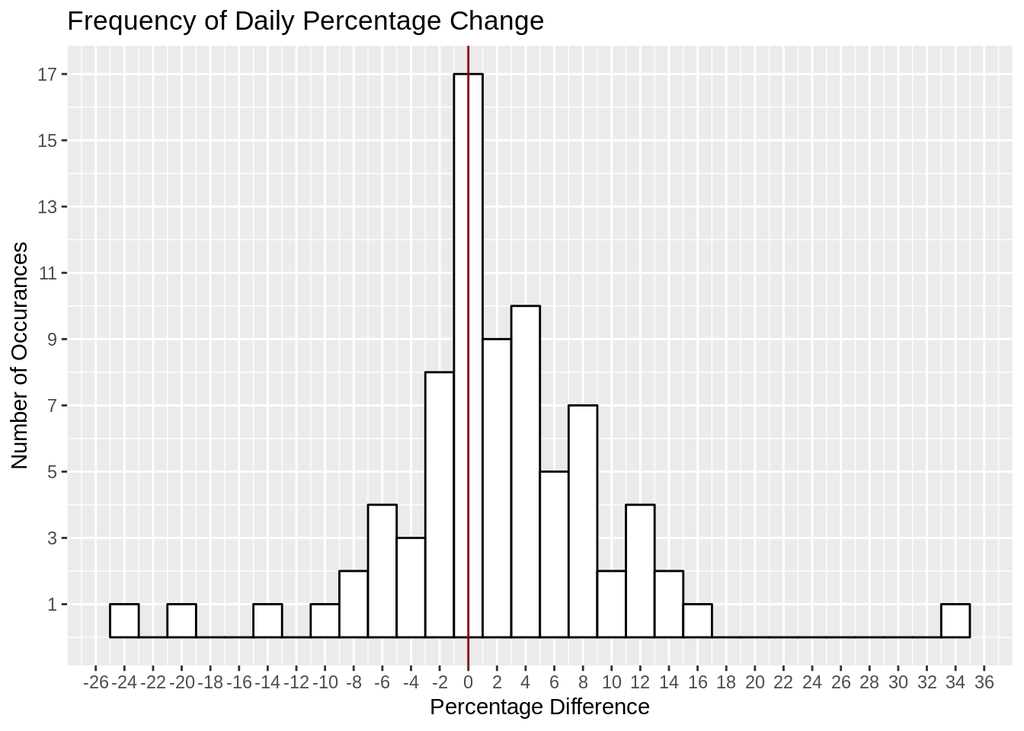

```r
Returns<-fortify(Returns)

ggplot(Returns, aes(x=SPY.Close) )+
  geom_histogram(binwidth = 2, color="black",fill="white",center=0)+
  scale_x_continuous(breaks=seq(-26, 36, 2))+
  geom_vline(xintercept = 0, col = 'darkred')+
  scale_y_continuous(breaks=seq(-1, 18, 2))+
  ggtitle("Frequency of Daily Percentage Change")+
  xlab("Percentage Difference")+
  ylab("Number of Occurances")
```

```r
#hist(Returns)
```

** A bit of background **

A common way to prediction method used to predict values in a time series (in our case dates) is the Autoregressive Integrated Moving Average (ARIMA) model.

ARIMA(P,D,Q)

AR stands for autogregressive, menaing it checks how much a variable correlates with itself. (P)

MA - A moving average of values you are using. 20 is a pretty common one for stocks (Q)

I - Degree of differencing needed to make the data stationary. Ex: degree of 1 replaces every value with the value minus the previous. Or degree 2, gets the difference of the difference (D)

The data needs to be stationary, basically needs to be horizontal, and one way to test is the Dicky Fuller test.

To make the data stationary you can take the log of the price, then do the differences of the log values.

When looking at the test, check that the p value is well under .5.

**What we did**

Here we decide to use the auto arima function. It looks for the best possible model to fit the data for us.

```r
arimaData <- auto.arima(SPY$SPY.Close)
arimaData
```

```
## Series: SPY$SPY.Close
## ARIMA(0,1,1) with drift
##
## Coefficients:
##           ma1   drift
##       -0.2421  0.5595
## s.e.   0.1178  0.1681
##
## sigma^2 estimated as 3.957:  log likelihood=-165.43
## AIC=336.87   AICc=337.19   BIC=343.97
```

Plot it

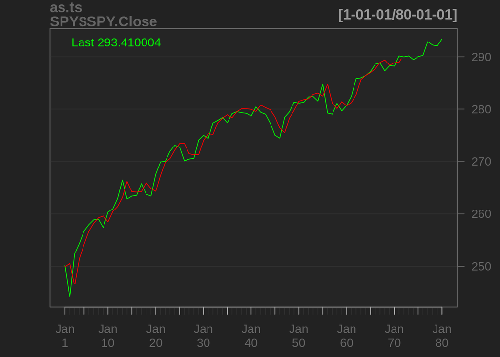

```r
chartSeries(as.ts(SPY$SPY.Close))
lines(fitted(arimaData), col='red')
```

As we can see the lines fit together pretty well

Let’s try to forecast the date

```r
# fit.forecast <- forecast.Arima(arimaData)
fit.forecast <- forecast(arimaData)
fit.forecast
```

```
##    Point Forecast    Lo 80    Hi 80    Lo 95    Hi 95
## 81       293.8294 291.2803 296.3786 289.9308 297.7280
## 82       294.3889 291.1903 297.5874 289.4971 299.2806
## 83       294.9483 291.2116 298.6851 289.2335 300.6632
## 84       295.5078 291.3011 299.7144 289.0743 301.9413
## 85       296.0672 291.4382 300.6963 288.9877 303.1468
## 86       296.6267 291.6106 301.6428 288.9553 304.2981
## 87       297.1862 291.8109 302.5614 288.9654 305.4069
## 88       297.7456 292.0337 303.4575 289.0100 306.4812
## 89       298.3051 292.2753 304.3349 289.0833 307.5269
## 90       298.8645 292.5328 305.1963 289.1809 308.5481
```

Source The main source I used was R for Data Science Cookbook By YuWei Chiu